# Risk Factor Analysis

## Outcome Variable

**Outcome Variable:** stunted

## Predictor Variables

**Intervention Variable:** mbmi

**Adjustment Set:**

- arm
- W_mage
- W_fage
- meducyrs
- feducyrs
- single
- brthmon
- delta_W_mage
- delta_W_fage
- delta_meducyrs
- delta_feducyrs
- delta_single
- delta_brthmon

## Stratifying Variables

The analysis was stratified on these variable(s):

- agecat
- studyid
- country

## Data Summary

| agecat | studyid | country | mbmi | stunted | n_cell | n |
| --- | --- | --- | --- | --- | --- | --- |
| Birth | ki0047075b-MAL-ED | BANGLADESH | Normal weight | 0 | 179 | 246 |
| Birth | ki0047075b-MAL-ED | BANGLADESH | Normal weight | 1 | 37 | 246 |
| Birth | ki0047075b-MAL-ED | BANGLADESH | Underweight | 0 | 25 | 246 |
| Birth | ki0047075b-MAL-ED | BANGLADESH | Underweight | 1 | 5 | 246 |
| Birth | ki0047075b-MAL-ED | BRAZIL | Normal weight | 0 | 158 | 184 |
| Birth | ki0047075b-MAL-ED | BRAZIL | Normal weight | 1 | 17 | 184 |
| Birth | ki0047075b-MAL-ED | BRAZIL | Underweight | 0 | 7 | 184 |
| Birth | ki0047075b-MAL-ED | BRAZIL | Underweight | 1 | 2 | 184 |
| Birth | ki0047075b-MAL-ED | INDIA | Normal weight | 0 | 134 | 198 |
| Birth | ki0047075b-MAL-ED | INDIA | Normal weight | 1 | 25 | 198 |
| Birth | ki0047075b-MAL-ED | INDIA | Underweight | 0 | 32 | 198 |
| Birth | ki0047075b-MAL-ED | INDIA | Underweight | 1 | 7 | 198 |
| Birth | ki0047075b-MAL-ED | NEPAL | Normal weight | 0 | 154 | 172 |
| Birth | ki0047075b-MAL-ED | NEPAL | Normal weight | 1 | 18 | 172 |
| Birth | ki0047075b-MAL-ED | NEPAL | Underweight | 0 | 0 | 172 |
| Birth | ki0047075b-MAL-ED | NEPAL | Underweight | 1 | 0 | 172 |
| Birth | ki0047075b-MAL-ED | PERU | Normal weight | 0 | 240 | 276 |
| Birth | ki0047075b-MAL-ED | PERU | Normal weight | 1 | 31 | 276 |
| Birth | ki0047075b-MAL-ED | PERU | Underweight | 0 | 3 | 276 |
| Birth | ki0047075b-MAL-ED | PERU | Underweight | 1 | 2 | 276 |
| Birth | ki0047075b-MAL-ED | SOUTH AFRICA | Normal weight | 0 | 200 | 228 |
| Birth | ki0047075b-MAL-ED | SOUTH AFRICA | Normal weight | 1 | 23 | 228 |
| Birth | ki0047075b-MAL-ED | SOUTH AFRICA | Underweight | 0 | 5 | 228 |
| Birth | ki0047075b-MAL-ED | SOUTH AFRICA | Underweight | 1 | 0 | 228 |
| Birth | ki0047075b-MAL-ED | TANZANIA, UNITED REPUBLIC OF | Normal weight | 0 | 98 | 121 |
| Birth | ki0047075b-MAL-ED | TANZANIA, UNITED REPUBLIC OF | Normal weight | 1 | 16 | 121 |
| Birth | ki0047075b-MAL-ED | TANZANIA, UNITED REPUBLIC OF | Underweight | 0 | 5 | 121 |
| Birth | ki0047075b-MAL-ED | TANZANIA, UNITED REPUBLIC OF | Underweight | 1 | 2 | 121 |
| Birth | ki1000304b-SAS-CompFeed | INDIA | Normal weight | 0 | 69 | 130 |
| Birth | ki1000304b-SAS-CompFeed | INDIA | Normal weight | 1 | 22 | 130 |

[output cut: 134 more lines]

The following strata were considered:

- agecat: 24 months, studyid: ki0047075b-MAL-ED, country: BANGLADESH
- agecat: 24 months, studyid: ki0047075b-MAL-ED, country: BRAZIL
- agecat: 24 months, studyid: ki0047075b-MAL-ED, country: INDIA
- agecat: 24 months, studyid: ki0047075b-MAL-ED, country: NEPAL
- agecat: 24 months, studyid: ki0047075b-MAL-ED, country: PERU
- agecat: 24 months, studyid: ki0047075b-MAL-ED, country: SOUTH AFRICA
- agecat: 24 months, studyid: ki0047075b-MAL-ED, country: TANZANIA, UNITED REPUBLIC OF
- agecat: 24 months, studyid: ki1017093-NIH-Birth, country: BANGLADESH
- agecat: 24 months, studyid: ki1017093b-PROVIDE, country: BANGLADESH
- agecat: 24 months, studyid: ki1017093c-NIH-Crypto, country: BANGLADESH
- agecat: 24 months, studyid: ki1066203-TanzaniaChild2, country: TANZANIA, UNITED REPUBLIC OF
- agecat: 24 months, studyid: ki1119695-PROBIT, country: BELARUS
- agecat: 24 months, studyid: ki1126311-ZVITAMBO, country: ZIMBABWE
- agecat: 24 months, studyid: ki1148112-LCNI-5, country: MALAWI
- agecat: 6 months, studyid: ki0047075b-MAL-ED, country: BANGLADESH
- agecat: 6 months, studyid: ki0047075b-MAL-ED, country: BRAZIL
- agecat: 6 months, studyid: ki0047075b-MAL-ED, country: INDIA
- agecat: 6 months, studyid: ki0047075b-MAL-ED, country: NEPAL
- agecat: 6 months, studyid: ki0047075b-MAL-ED, country: PERU
- agecat: 6 months, studyid: ki0047075b-MAL-ED, country: SOUTH AFRICA
- agecat: 6 months, studyid: ki0047075b-MAL-ED, country: TANZANIA, UNITED REPUBLIC OF
- agecat: 6 months, studyid: ki1000304b-SAS-CompFeed, country: INDIA
- agecat: 6 months, studyid: ki1017093-NIH-Birth, country: BANGLADESH
- agecat: 6 months, studyid: ki1017093b-PROVIDE, country: BANGLADESH
- agecat: 6 months, studyid: ki1017093c-NIH-Crypto, country: BANGLADESH
- agecat: 6 months, studyid: ki1066203-TanzaniaChild2, country: TANZANIA, UNITED REPUBLIC OF
- agecat: 6 months, studyid: ki1119695-PROBIT, country: BELARUS
- agecat: 6 months, studyid: ki1126311-ZVITAMBO, country: ZIMBABWE
- agecat: 6 months, studyid: ki1148112-LCNI-5, country: MALAWI
- agecat: Birth, studyid: ki0047075b-MAL-ED, country: BANGLADESH
- agecat: Birth, studyid: ki0047075b-MAL-ED, country: BRAZIL
- agecat: Birth, studyid: ki0047075b-MAL-ED, country: INDIA
- agecat: Birth, studyid: ki0047075b-MAL-ED, country: NEPAL
- agecat: Birth, studyid: ki0047075b-MAL-ED, country: PERU
- agecat: Birth, studyid: ki0047075b-MAL-ED, country: SOUTH AFRICA
- agecat: Birth, studyid: ki0047075b-MAL-ED, country: TANZANIA, UNITED REPUBLIC OF
- agecat: Birth, studyid: ki1000304b-SAS-CompFeed, country: INDIA
- agecat: Birth, studyid: ki1017093-NIH-Birth, country: BANGLADESH
- agecat: Birth, studyid: ki1017093c-NIH-Crypto, country: BANGLADESH
- agecat: Birth, studyid: ki1119695-PROBIT, country: BELARUS
- agecat: Birth, studyid: ki1126311-ZVITAMBO, country: ZIMBABWE

### Dropped Strata

Some strata were dropped due to rare outcomes:

- agecat: Birth, studyid: ki0047075b-MAL-ED, country: BRAZIL
- agecat: Birth, studyid: ki0047075b-MAL-ED, country: NEPAL
- agecat: Birth, studyid: ki0047075b-MAL-ED, country: PERU
- agecat: Birth, studyid: ki0047075b-MAL-ED, country: SOUTH AFRICA
- agecat: Birth, studyid: ki0047075b-MAL-ED, country: TANZANIA, UNITED REPUBLIC OF
- agecat: Birth, studyid: ki1017093-NIH-Birth, country: BANGLADESH
- agecat: Birth, studyid: ki1017093c-NIH-Crypto, country: BANGLADESH
- agecat: Birth, studyid: ki1119695-PROBIT, country: BELARUS
- agecat: 6 months, studyid: ki0047075b-MAL-ED, country: BRAZIL
- agecat: 6 months, studyid: ki0047075b-MAL-ED, country: NEPAL
- agecat: 6 months, studyid: ki0047075b-MAL-ED, country: PERU
- agecat: 6 months, studyid: ki0047075b-MAL-ED, country: SOUTH AFRICA
- agecat: 6 months, studyid: ki0047075b-MAL-ED, country: TANZANIA, UNITED REPUBLIC OF
- agecat: 6 months, studyid: ki1066203-TanzaniaChild2, country: TANZANIA, UNITED REPUBLIC OF
- agecat: 24 months, studyid: ki0047075b-MAL-ED, country: BRAZIL
- agecat: 24 months, studyid: ki0047075b-MAL-ED, country: NEPAL
- agecat: 24 months, studyid: ki0047075b-MAL-ED, country: PERU
- agecat: 24 months, studyid: ki0047075b-MAL-ED, country: SOUTH AFRICA
- agecat: 24 months, studyid: ki0047075b-MAL-ED, country: TANZANIA, UNITED REPUBLIC OF
- agecat: 24 months, studyid: ki1066203-TanzaniaChild2, country: TANZANIA, UNITED REPUBLIC OF

## Methods Detail

We’re interested in the causal parameters $E[Y_a]$ for all values of $a \in \mathcal{A}$. These parameters represent the mean outcome if, possibly contrary to fact, we intervened to set all units to have $A=a$. Under the randomization and positivity assumptions, these are identified by the statistical parameters $\psi_a=E_W[E_{Y|A,W}(Y|A=a,W)]$. In addition, we’re interested in the mean of $Y$, $E[Y]$ under no intervention (the observed mean). We will estimate these parameters by using SuperLearner to fit the relevant likelihood factors – $E_{Y|A,W}(Y|A=a,W)$ and $p(A=a|W)$, and then updating our likelihood fit using a joint TMLE.

For unadjusted analyses ($W=\{\}$), initial likelihoods were estimated using Lrnr_glm to estimate the simple $E(Y|A)$ and Lrnr_mean to estimate $p(A)$. For adjusted analyses, a small library containing Lrnr_glmnet, Lrnr_xgboost, and Lrnr_mean was used.

Having estimated these parameters, we will then use the delta method to estimate relative risks and attributable risks relative to a prespecified baseline level of $A$.

# Results Detail

## Results Plots

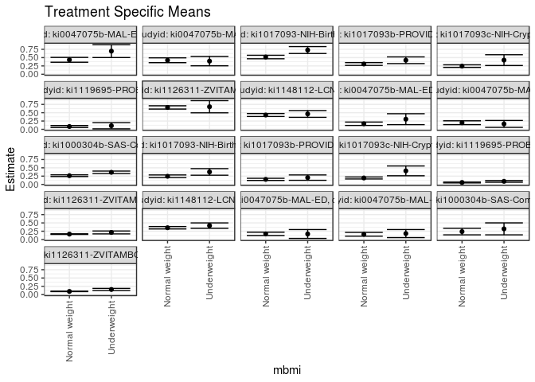

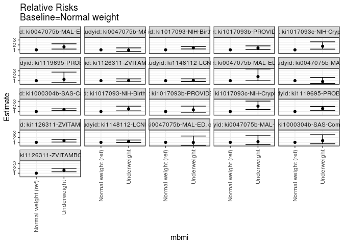

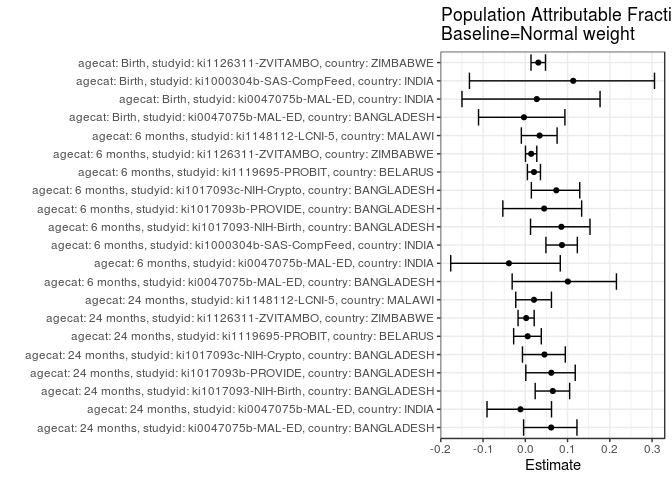

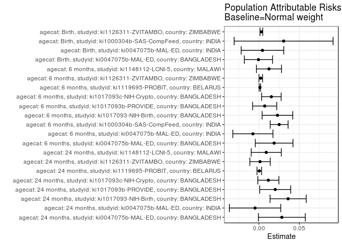

## Results Table

### Parameter: TSM

| agecat | studyid | country | intervention_level | baseline_level | estimate | ci_lower | ci_upper |
| --- | --- | --- | --- | --- | --- | --- | --- |
| Birth | ki0047075b-MAL-ED | BANGLADESH | Normal weight | NA | 0.1712963 | 0.1209486 | 0.2216440 |
| Birth | ki0047075b-MAL-ED | BANGLADESH | Underweight | NA | 0.1666667 | 0.0330361 | 0.3002972 |
| Birth | ki0047075b-MAL-ED | INDIA | Normal weight | NA | 0.1572327 | 0.1005077 | 0.2139577 |
| Birth | ki0047075b-MAL-ED | INDIA | Underweight | NA | 0.1794872 | 0.0587407 | 0.3002337 |
| Birth | ki1000304b-SAS-CompFeed | INDIA | Normal weight | NA | 0.2387012 | 0.1404216 | 0.3369807 |
| Birth | ki1000304b-SAS-CompFeed | INDIA | Underweight | NA | 0.3206604 | 0.1405802 | 0.5007406 |
| Birth | ki1126311-ZVITAMBO | ZIMBABWE | Normal weight | NA | 0.0961754 | 0.0901219 | 0.1022290 |
| Birth | ki1126311-ZVITAMBO | ZIMBABWE | Underweight | NA | 0.1548126 | 0.1218921 | 0.1877331 |
| 6 months | ki0047075b-MAL-ED | BANGLADESH | Normal weight | NA | 0.1679250 | 0.1170921 | 0.2187579 |
| 6 months | ki0047075b-MAL-ED | BANGLADESH | Underweight | NA | 0.3054604 | 0.1410990 | 0.4698218 |
| 6 months | ki0047075b-MAL-ED | INDIA | Normal weight | NA | 0.1989247 | 0.1414339 | 0.2564156 |
| 6 months | ki0047075b-MAL-ED | INDIA | Underweight | NA | 0.1632653 | 0.0595562 | 0.2669744 |
| 6 months | ki1000304b-SAS-CompFeed | INDIA | Normal weight | NA | 0.2634954 | 0.2381412 | 0.2888497 |
| 6 months | ki1000304b-SAS-CompFeed | INDIA | Underweight | NA | 0.3643366 | 0.3272546 | 0.4014185 |
| 6 months | ki1017093-NIH-Birth | BANGLADESH | Normal weight | NA | 0.2452491 | 0.2051691 | 0.2853290 |
| 6 months | ki1017093-NIH-Birth | BANGLADESH | Underweight | NA | 0.3762780 | 0.2769621 | 0.4755939 |
| 6 months | ki1017093b-PROVIDE | BANGLADESH | Normal weight | NA | 0.1526655 | 0.1202545 | 0.1850764 |
| 6 months | ki1017093b-PROVIDE | BANGLADESH | Underweight | NA | 0.2043779 | 0.1236738 | 0.2850821 |
| 6 months | ki1017093c-NIH-Crypto | BANGLADESH | Normal weight | NA | 0.1944075 | 0.1636828 | 0.2251322 |
| 6 months | ki1017093c-NIH-Crypto | BANGLADESH | Underweight | NA | 0.4083286 | 0.2606083 | 0.5560490 |
| 6 months | ki1119695-PROBIT | BELARUS | Normal weight | NA | 0.0586473 | 0.0457921 | 0.0715025 |
| 6 months | ki1119695-PROBIT | BELARUS | Underweight | NA | 0.0934770 | 0.0671885 | 0.1197655 |
| 6 months | ki1126311-ZVITAMBO | ZIMBABWE | Normal weight | NA | 0.1631248 | 0.1542978 | 0.1719519 |
| 6 months | ki1126311-ZVITAMBO | ZIMBABWE | Underweight | NA | 0.2136677 | 0.1697472 | 0.2575883 |
| 6 months | ki1148112-LCNI-5 | MALAWI | Normal weight | NA | 0.3547971 | 0.3190459 | 0.3905483 |
| 6 months | ki1148112-LCNI-5 | MALAWI | Underweight | NA | 0.4190521 | 0.3381839 | 0.4999203 |
| 24 months | ki0047075b-MAL-ED | BANGLADESH | Normal weight | NA | 0.4339665 | 0.3611623 | 0.5067707 |
| 24 months | ki0047075b-MAL-ED | BANGLADESH | Underweight | NA | 0.6960361 | 0.5020944 | 0.8899778 |
| 24 months | ki0047075b-MAL-ED | INDIA | Normal weight | NA | 0.4206804 | 0.3482865 | 0.4930744 |
| 24 months | ki0047075b-MAL-ED | INDIA | Underweight | NA | 0.3948571 | 0.2542295 | 0.5354846 |
| 24 months | ki1017093-NIH-Birth | BANGLADESH | Normal weight | NA | 0.5187042 | 0.4661555 | 0.5712530 |
| 24 months | ki1017093-NIH-Birth | BANGLADESH | Underweight | NA | 0.7278633 | 0.6244117 | 0.8313149 |
| 24 months | ki1017093b-PROVIDE | BANGLADESH | Normal weight | NA | 0.3079554 | 0.2660099 | 0.3499009 |
| 24 months | ki1017093b-PROVIDE | BANGLADESH | Underweight | NA | 0.4214069 | 0.3209541 | 0.5218596 |
| 24 months | ki1017093c-NIH-Crypto | BANGLADESH | Normal weight | NA | 0.2451768 | 0.2061705 | 0.2841831 |
| 24 months | ki1017093c-NIH-Crypto | BANGLADESH | Underweight | NA | 0.4247633 | 0.2622544 | 0.5872722 |
| 24 months | ki1119695-PROBIT | BELARUS | Normal weight | NA | 0.0849096 | 0.0555081 | 0.1143111 |
| 24 months | ki1119695-PROBIT | BELARUS | Underweight | NA | 0.1073578 | 0.0136727 | 0.2010429 |
| 24 months | ki1126311-ZVITAMBO | ZIMBABWE | Normal weight | NA | 0.6590909 | 0.6095065 | 0.7086754 |
| 24 months | ki1126311-ZVITAMBO | ZIMBABWE | Underweight | NA | 0.6800000 | 0.4969017 | 0.8630983 |
| 24 months | ki1148112-LCNI-5 | MALAWI | Normal weight | NA | 0.4311647 | 0.3867721 | 0.4755574 |
| 24 months | ki1148112-LCNI-5 | MALAWI | Underweight | NA | 0.4636117 | 0.3613051 | 0.5659183 |

### Parameter: E(Y)

| agecat | studyid | country | intervention_level | baseline_level | estimate | ci_lower | ci_upper |
| --- | --- | --- | --- | --- | --- | --- | --- |
| Birth | ki0047075b-MAL-ED | BANGLADESH | NA | NA | 0.1707317 | 0.1236156 | 0.2178478 |
| Birth | ki0047075b-MAL-ED | INDIA | NA | NA | 0.1616162 | 0.1102143 | 0.2130180 |
| Birth | ki1000304b-SAS-CompFeed | INDIA | NA | NA | 0.2692308 | 0.1695525 | 0.3689090 |
| Birth | ki1126311-ZVITAMBO | ZIMBABWE | NA | NA | 0.0992319 | 0.0932615 | 0.1052022 |
| 6 months | ki0047075b-MAL-ED | BANGLADESH | NA | NA | 0.1867220 | 0.1374205 | 0.2360234 |
| 6 months | ki0047075b-MAL-ED | INDIA | NA | NA | 0.1914894 | 0.1410749 | 0.2419038 |
| 6 months | ki1000304b-SAS-CompFeed | INDIA | NA | NA | 0.2885086 | 0.2628530 | 0.3141641 |
| 6 months | ki1017093-NIH-Birth | BANGLADESH | NA | NA | 0.2681564 | 0.2306532 | 0.3056597 |
| 6 months | ki1017093b-PROVIDE | BANGLADESH | NA | NA | 0.1597938 | 0.1299995 | 0.1895881 |
| 6 months | ki1017093c-NIH-Crypto | BANGLADESH | NA | NA | 0.2097902 | 0.1799252 | 0.2396552 |
| 6 months | ki1119695-PROBIT | BELARUS | NA | NA | 0.0598756 | 0.0470544 | 0.0726968 |
| 6 months | ki1126311-ZVITAMBO | ZIMBABWE | NA | NA | 0.1654241 | 0.1567862 | 0.1740620 |
| 6 months | ki1148112-LCNI-5 | MALAWI | NA | NA | 0.3672249 | 0.3345288 | 0.3999210 |
| 24 months | ki0047075b-MAL-ED | BANGLADESH | NA | NA | 0.4622642 | 0.3949918 | 0.5295365 |
| 24 months | ki0047075b-MAL-ED | INDIA | NA | NA | 0.4159292 | 0.3515272 | 0.4803312 |
| 24 months | ki1017093-NIH-Birth | BANGLADESH | NA | NA | 0.5547786 | 0.5076945 | 0.6018626 |
| 24 months | ki1017093b-PROVIDE | BANGLADESH | NA | NA | 0.3281250 | 0.2897474 | 0.3665026 |
| 24 months | ki1017093c-NIH-Crypto | BANGLADESH | NA | NA | 0.2568093 | 0.2190047 | 0.2946140 |
| 24 months | ki1119695-PROBIT | BELARUS | NA | NA | 0.0853933 | 0.0554084 | 0.1153781 |
| 24 months | ki1126311-ZVITAMBO | ZIMBABWE | NA | NA | 0.6604775 | 0.6126125 | 0.7083424 |
| 24 months | ki1148112-LCNI-5 | MALAWI | NA | NA | 0.4402080 | 0.3996684 | 0.4807475 |

### Parameter: RR

| agecat | studyid | country | intervention_level | baseline_level | estimate | ci_lower | ci_upper |
| --- | --- | --- | --- | --- | --- | --- | --- |
| Birth | ki0047075b-MAL-ED | BANGLADESH | Normal weight | Normal weight | 1.0000000 | 1.0000000 | 1.000000 |
| Birth | ki0047075b-MAL-ED | BANGLADESH | Underweight | Normal weight | 0.9729730 | 0.4142200 | 2.285444 |
| Birth | ki0047075b-MAL-ED | INDIA | Normal weight | Normal weight | 1.0000000 | 1.0000000 | 1.000000 |
| Birth | ki0047075b-MAL-ED | INDIA | Underweight | Normal weight | 1.1415385 | 0.5320672 | 2.449146 |
| Birth | ki1000304b-SAS-CompFeed | INDIA | Normal weight | Normal weight | 1.0000000 | 1.0000000 | 1.000000 |
| Birth | ki1000304b-SAS-CompFeed | INDIA | Underweight | Normal weight | 1.3433551 | 0.7093581 | 2.543994 |
| Birth | ki1126311-ZVITAMBO | ZIMBABWE | Normal weight | Normal weight | 1.0000000 | 1.0000000 | 1.000000 |
| Birth | ki1126311-ZVITAMBO | ZIMBABWE | Underweight | Normal weight | 1.6096898 | 1.2894692 | 2.009432 |
| 6 months | ki0047075b-MAL-ED | BANGLADESH | Normal weight | Normal weight | 1.0000000 | 1.0000000 | 1.000000 |
| 6 months | ki0047075b-MAL-ED | BANGLADESH | Underweight | Normal weight | 1.8190285 | 0.9805149 | 3.374620 |
| 6 months | ki0047075b-MAL-ED | INDIA | Normal weight | Normal weight | 1.0000000 | 1.0000000 | 1.000000 |
| 6 months | ki0047075b-MAL-ED | INDIA | Underweight | Normal weight | 0.8207391 | 0.4084345 | 1.649255 |
| 6 months | ki1000304b-SAS-CompFeed | INDIA | Normal weight | Normal weight | 1.0000000 | 1.0000000 | 1.000000 |
| 6 months | ki1000304b-SAS-CompFeed | INDIA | Underweight | Normal weight | 1.3827055 | 1.2391115 | 1.542940 |
| 6 months | ki1017093-NIH-Birth | BANGLADESH | Normal weight | Normal weight | 1.0000000 | 1.0000000 | 1.000000 |
| 6 months | ki1017093-NIH-Birth | BANGLADESH | Underweight | Normal weight | 1.5342686 | 1.1246785 | 2.093025 |
| 6 months | ki1017093b-PROVIDE | BANGLADESH | Normal weight | Normal weight | 1.0000000 | 1.0000000 | 1.000000 |
| 6 months | ki1017093b-PROVIDE | BANGLADESH | Underweight | Normal weight | 1.3387307 | 0.8546907 | 2.096899 |
| 6 months | ki1017093c-NIH-Crypto | BANGLADESH | Normal weight | Normal weight | 1.0000000 | 1.0000000 | 1.000000 |
| 6 months | ki1017093c-NIH-Crypto | BANGLADESH | Underweight | Normal weight | 2.1003751 | 1.4137605 | 3.120455 |
| 6 months | ki1119695-PROBIT | BELARUS | Normal weight | Normal weight | 1.0000000 | 1.0000000 | 1.000000 |
| 6 months | ki1119695-PROBIT | BELARUS | Underweight | Normal weight | 1.5938854 | 1.2429056 | 2.043977 |
| 6 months | ki1126311-ZVITAMBO | ZIMBABWE | Normal weight | Normal weight | 1.0000000 | 1.0000000 | 1.000000 |
| 6 months | ki1126311-ZVITAMBO | ZIMBABWE | Underweight | Normal weight | 1.3098420 | 1.0590114 | 1.620083 |
| 6 months | ki1148112-LCNI-5 | MALAWI | Normal weight | Normal weight | 1.0000000 | 1.0000000 | 1.000000 |
| 6 months | ki1148112-LCNI-5 | MALAWI | Underweight | Normal weight | 1.1811035 | 0.9500256 | 1.468387 |
| 24 months | ki0047075b-MAL-ED | BANGLADESH | Normal weight | Normal weight | 1.0000000 | 1.0000000 | 1.000000 |
| 24 months | ki0047075b-MAL-ED | BANGLADESH | Underweight | Normal weight | 1.6038936 | 1.1570397 | 2.223324 |
| 24 months | ki0047075b-MAL-ED | INDIA | Normal weight | Normal weight | 1.0000000 | 1.0000000 | 1.000000 |
| 24 months | ki0047075b-MAL-ED | INDIA | Underweight | Normal weight | 0.9386153 | 0.6331886 | 1.391369 |
| 24 months | ki1017093-NIH-Birth | BANGLADESH | Normal weight | Normal weight | 1.0000000 | 1.0000000 | 1.000000 |
| 24 months | ki1017093-NIH-Birth | BANGLADESH | Underweight | Normal weight | 1.4032337 | 1.1779926 | 1.671543 |
| 24 months | ki1017093b-PROVIDE | BANGLADESH | Normal weight | Normal weight | 1.0000000 | 1.0000000 | 1.000000 |
| 24 months | ki1017093b-PROVIDE | BANGLADESH | Underweight | Normal weight | 1.3684023 | 1.0397154 | 1.800998 |
| 24 months | ki1017093c-NIH-Crypto | BANGLADESH | Normal weight | Normal weight | 1.0000000 | 1.0000000 | 1.000000 |
| 24 months | ki1017093c-NIH-Crypto | BANGLADESH | Underweight | Normal weight | 1.7324776 | 1.1449241 | 2.621552 |
| 24 months | ki1119695-PROBIT | BELARUS | Normal weight | Normal weight | 1.0000000 | 1.0000000 | 1.000000 |
| 24 months | ki1119695-PROBIT | BELARUS | Underweight | Normal weight | 1.2643778 | 0.5842108 | 2.736429 |
| 24 months | ki1126311-ZVITAMBO | ZIMBABWE | Normal weight | Normal weight | 1.0000000 | 1.0000000 | 1.000000 |
| 24 months | ki1126311-ZVITAMBO | ZIMBABWE | Underweight | Normal weight | 1.0317241 | 0.7800922 | 1.364524 |
| 24 months | ki1148112-LCNI-5 | MALAWI | Normal weight | Normal weight | 1.0000000 | 1.0000000 | 1.000000 |
| 24 months | ki1148112-LCNI-5 | MALAWI | Underweight | Normal weight | 1.0752543 | 0.8425780 | 1.372184 |

### Parameter: PAR

| agecat | studyid | country | intervention_level | baseline_level | estimate | ci_lower | ci_upper |
| --- | --- | --- | --- | --- | --- | --- | --- |
| Birth | ki0047075b-MAL-ED | BANGLADESH | Normal weight | NA | -0.0005646 | -0.0179803 | 0.0168512 |
| Birth | ki0047075b-MAL-ED | INDIA | Normal weight | NA | 0.0043835 | -0.0219227 | 0.0306897 |
| Birth | ki1000304b-SAS-CompFeed | INDIA | Normal weight | NA | 0.0305296 | -0.0305768 | 0.0916360 |
| Birth | ki1126311-ZVITAMBO | ZIMBABWE | Normal weight | NA | 0.0030564 | 0.0013474 | 0.0047655 |
| 6 months | ki0047075b-MAL-ED | BANGLADESH | Normal weight | NA | 0.0187970 | -0.0044796 | 0.0420736 |
| 6 months | ki0047075b-MAL-ED | INDIA | Normal weight | NA | -0.0074354 | -0.0322297 | 0.0173590 |
| 6 months | ki1000304b-SAS-CompFeed | INDIA | Normal weight | NA | 0.0250131 | 0.0139735 | 0.0360528 |
| 6 months | ki1017093-NIH-Birth | BANGLADESH | Normal weight | NA | 0.0229073 | 0.0039719 | 0.0418428 |
| 6 months | ki1017093b-PROVIDE | BANGLADESH | Normal weight | NA | 0.0071283 | -0.0077789 | 0.0220356 |
| 6 months | ki1017093c-NIH-Crypto | BANGLADESH | Normal weight | NA | 0.0153827 | 0.0032947 | 0.0274708 |
| 6 months | ki1119695-PROBIT | BELARUS | Normal weight | NA | 0.0012284 | 0.0003430 | 0.0021137 |
| 6 months | ki1126311-ZVITAMBO | ZIMBABWE | Normal weight | NA | 0.0022993 | 0.0000824 | 0.0045161 |
| 6 months | ki1148112-LCNI-5 | MALAWI | Normal weight | NA | 0.0124278 | -0.0030939 | 0.0279495 |
| 24 months | ki0047075b-MAL-ED | BANGLADESH | Normal weight | NA | 0.0282976 | -0.0006470 | 0.0572422 |
| 24 months | ki0047075b-MAL-ED | INDIA | Normal weight | NA | -0.0047512 | -0.0364758 | 0.0269734 |
| 24 months | ki1017093-NIH-Birth | BANGLADESH | Normal weight | NA | 0.0360743 | 0.0137340 | 0.0584147 |
| 24 months | ki1017093b-PROVIDE | BANGLADESH | Normal weight | NA | 0.0201696 | 0.0010077 | 0.0393315 |
| 24 months | ki1017093c-NIH-Crypto | BANGLADESH | Normal weight | NA | 0.0116325 | -0.0014040 | 0.0246691 |
| 24 months | ki1119695-PROBIT | BELARUS | Normal weight | NA | 0.0004837 | -0.0023468 | 0.0033141 |
| 24 months | ki1126311-ZVITAMBO | ZIMBABWE | Normal weight | NA | 0.0013865 | -0.0112036 | 0.0139767 |
| 24 months | ki1148112-LCNI-5 | MALAWI | Normal weight | NA | 0.0090433 | -0.0095332 | 0.0276197 |

### Parameter: PAF

| agecat | studyid | country | intervention_level | baseline_level | estimate | ci_lower | ci_upper |
| --- | --- | --- | --- | --- | --- | --- | --- |
| Birth | ki0047075b-MAL-ED | BANGLADESH | Normal weight | NA | -0.0033069 | -0.1106765 | 0.0936833 |
| Birth | ki0047075b-MAL-ED | INDIA | Normal weight | NA | 0.0271227 | -0.1498865 | 0.1768837 |
| Birth | ki1000304b-SAS-CompFeed | INDIA | Normal weight | NA | 0.1133957 | -0.1322091 | 0.3057226 |
| Birth | ki1126311-ZVITAMBO | ZIMBABWE | Normal weight | NA | 0.0308011 | 0.0135009 | 0.0477978 |
| 6 months | ki0047075b-MAL-ED | BANGLADESH | Normal weight | NA | 0.1006683 | -0.0311205 | 0.2156129 |
| 6 months | ki0047075b-MAL-ED | INDIA | Normal weight | NA | -0.0388292 | -0.1764940 | 0.0827271 |
| 6 months | ki1000304b-SAS-CompFeed | INDIA | Normal weight | NA | 0.0866981 | 0.0487747 | 0.1231096 |
| 6 months | ki1017093-NIH-Birth | BANGLADESH | Normal weight | NA | 0.0854253 | 0.0123650 | 0.1530810 |
| 6 months | ki1017093b-PROVIDE | BANGLADESH | Normal weight | NA | 0.0446097 | -0.0531823 | 0.1333213 |
| 6 months | ki1017093c-NIH-Crypto | BANGLADESH | Normal weight | NA | 0.0733243 | 0.0143176 | 0.1287987 |
| 6 months | ki1119695-PROBIT | BELARUS | Normal weight | NA | 0.0205155 | 0.0049509 | 0.0358365 |
| 6 months | ki1126311-ZVITAMBO | ZIMBABWE | Normal weight | NA | 0.0138993 | 0.0004178 | 0.0271990 |
| 6 months | ki1148112-LCNI-5 | MALAWI | Normal weight | NA | 0.0338424 | -0.0093769 | 0.0752112 |
| 24 months | ki0047075b-MAL-ED | BANGLADESH | Normal weight | NA | 0.0612153 | -0.0040566 | 0.1222440 |
| 24 months | ki0047075b-MAL-ED | INDIA | Normal weight | NA | -0.0114231 | -0.0906285 | 0.0620301 |
| 24 months | ki1017093-NIH-Birth | BANGLADESH | Normal weight | NA | 0.0650247 | 0.0233599 | 0.1049120 |
| 24 months | ki1017093b-PROVIDE | BANGLADESH | Normal weight | NA | 0.0614693 | 0.0011643 | 0.1181333 |
| 24 months | ki1017093c-NIH-Crypto | BANGLADESH | Normal weight | NA | 0.0452964 | -0.0067488 | 0.0946510 |
| 24 months | ki1119695-PROBIT | BELARUS | Normal weight | NA | 0.0056640 | -0.0275828 | 0.0378351 |
| 24 months | ki1126311-ZVITAMBO | ZIMBABWE | Normal weight | NA | 0.0020993 | -0.0171479 | 0.0209823 |
| 24 months | ki1148112-LCNI-5 | MALAWI | Normal weight | NA | 0.0205432 | -0.0225992 | 0.0618654 |